# Sentiment Analysis using the AFINN Lexicon

```r
library(here)
library(dplyr)
library(tidytext)
library(tidyr)
library(knitr)
library(ggplot2)
```

Sentiment analysis allows us to use standard lexicons to explore the sentiments expressed in texts.

This is a basic sentiment analysis. Notice that it assumes that two data sets have been created and saved in the data folder. I use `knitr::knit_exit()` to stop knitting if either of the data sets are not present.

```r
if (file.exists(here("data/qs_tokens.rda"))) {
     load(here("data/qs_tokens.rda"))
} else {
  print("qs_tokens not present.")
  knitr::knit_exit()
}
```

We will use the tokenized data (one word per line). In this data you should also have a row number variable and a variable that defines which chapter/story/section the word is in. We will be using those variables to help us to explore sentiments in the text.

In AFINN, each word (in the lexicon) has a numeric rating between -5 and 5.

A “join” is a method of putting two data frames together. An inner join keeps only those rows that are present in both data sets. The “by” option indicates the variable or variables that will be used to match the rows in the two data sets.

This data is only going to include words that have sentiment values.

```r
afinn <- get_sentiments("afinn")
afinn |> inner_join( qs_tokens, by = "word", multiple = "all") -> qs_afinn
```

```r
table(qs_afinn$value)
```

```
##
##   -5   -4   -3   -2   -1    1    2    3    4    5
##    2   11  498 1603  825 1275 1384  615  107    1
```

```r
table(qs_afinn$value) |> prop.table() |>round(2)
```

```
##
##   -5   -4   -3   -2   -1    1    2    3    4    5
## 0.00 0.00 0.08 0.25 0.13 0.20 0.22 0.10 0.02 0.00
```

Overall the words in our files are more positive than negative.

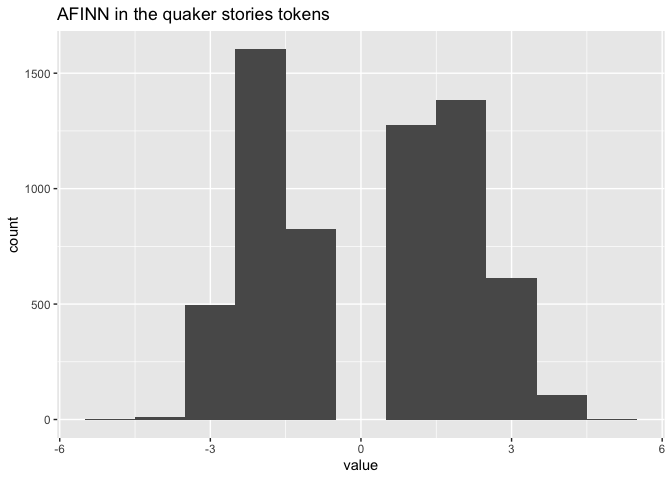

```r
ggplot(qs_afinn, aes(x = value)) + geom_histogram(bins = 11) +
  labs(title = "AFINN in the quaker stories tokens")
```

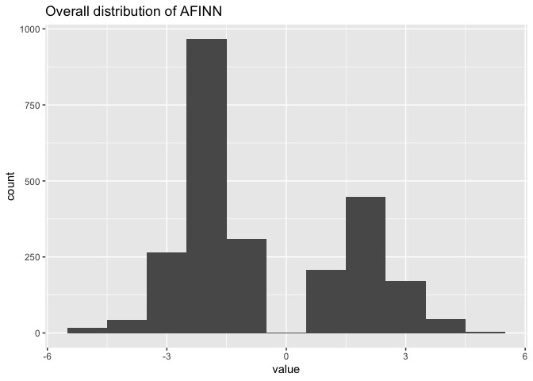

```r
ggplot(afinn, aes(x = value)) + geom_histogram(bins = 11) +
  labs(title= "Overall distribution of AFINN")
```

Interestingly, when stories appropriate for younger audiences are compared to those that are not, the younger-oriented stories are, if anything, slightly more negative although there are only small differences..

## Stories for younger versus older readers

Since the values are numeric we can do things such as make box plots comparing type of sections or those for older and younger readers.

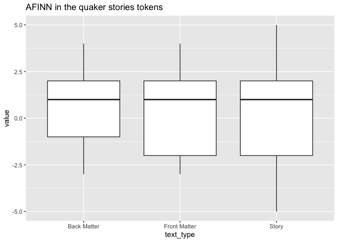

```r
qs_afinn |>
ggplot(aes(x = text_type, y = value)) +
  geom_boxplot() +
  labs(title = "AFINN in the quaker stories tokens")
```

In this case what we see is that the medians are not that different.

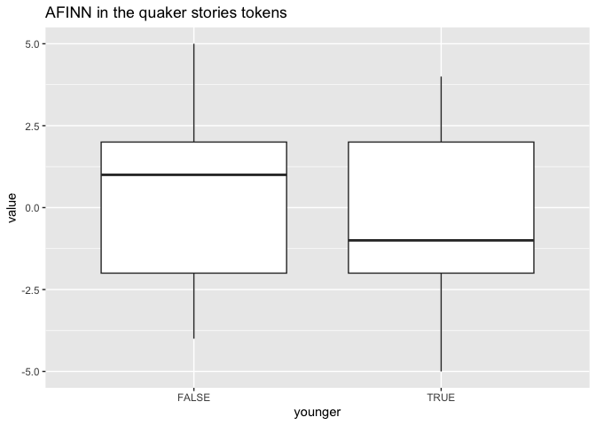

```r
qs_afinn |>
  filter(text_type == "Story") |>
ggplot(aes(x = younger, y = value)) +
  geom_boxplot() +
  labs(title = "AFINN in the quaker stories tokens")
```

How much variation is there from story to story?

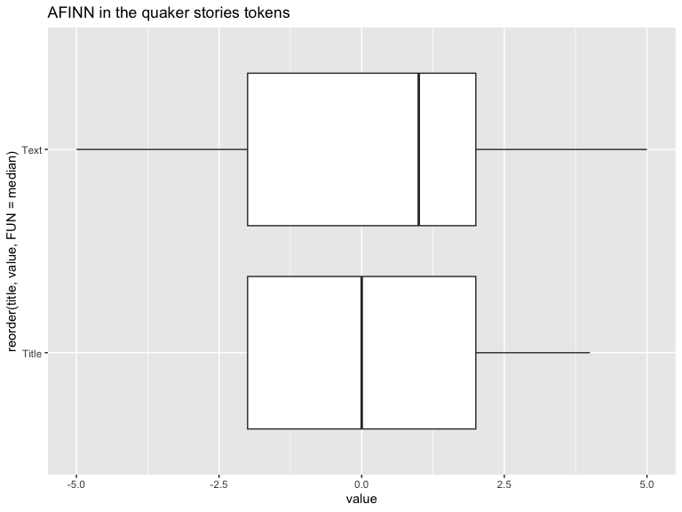

```r
qs_afinn |>
ggplot(aes(x = reorder(title, value, FUN = median),
           y = value)) +
  geom_boxplot() +
  coord_flip() +
  labs(title = "AFINN in the quaker stories tokens")
```

Another thing to look at will be how sentiments change during the stories.

How do we have to fix this to make it meaningful? we can change the visualization of the charts by giving a different graph to each story.

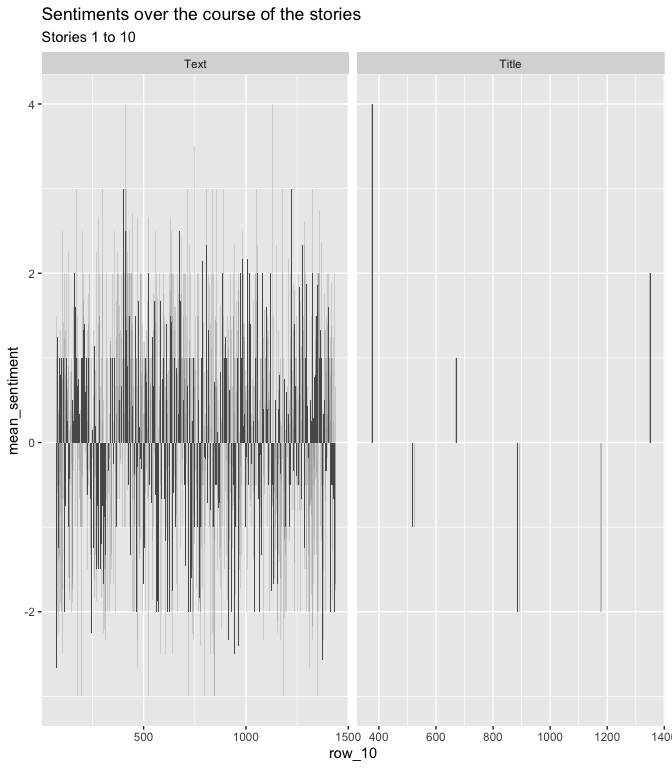

```r
 qs_afinn |>
  filter(text_type == "Story") |>
  # Select just the first 10 stories
  filter(title %in% unique(title)[1:10]) |>
  # I'm going to make groups of 10 rows to do together.
  # I could use modulo instead.
  mutate(row_10 = round(row_number/10), 0) |>
  arrange(row_10) |>
  group_by(title, row_10) |>
  summarize(mean_sentiment = mean(value)) |>
ggplot( aes(x= row_10, y = mean_sentiment)) +
  geom_col(show.legend = FALSE) +
  facet_wrap(~title, ncol = 2, scales = "free_x") +
  labs(title = "Sentiments over the course of the stories",
      subtitle = "Stories 1 to 10")
```

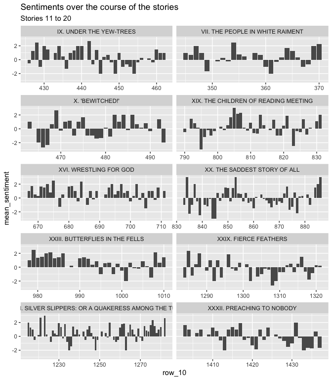

```r
 qs_afinn |>
  filter(text_type == "Story") |>
  # Select just the first 10 stories
  filter(section_title %in% unique(section_title)[11:20]) |>
  # I'm going to make groups of 10 rows to do together.
  # I could use modulo instead.
  mutate(row_10 = round(row_number/10), 0) |>
  arrange(row_10) |>
  group_by(section_title, row_10) |>
  summarize(mean_sentiment = mean(value)) |>
ggplot( aes(x= row_10, y = mean_sentiment)) +
  geom_col(show.legend = FALSE) +
  facet_wrap(~section_title, ncol = 2, scales = "free_x") +
  labs(title = "Sentiments over the course of the stories",
      subtitle = "Stories 11 to 20")
```

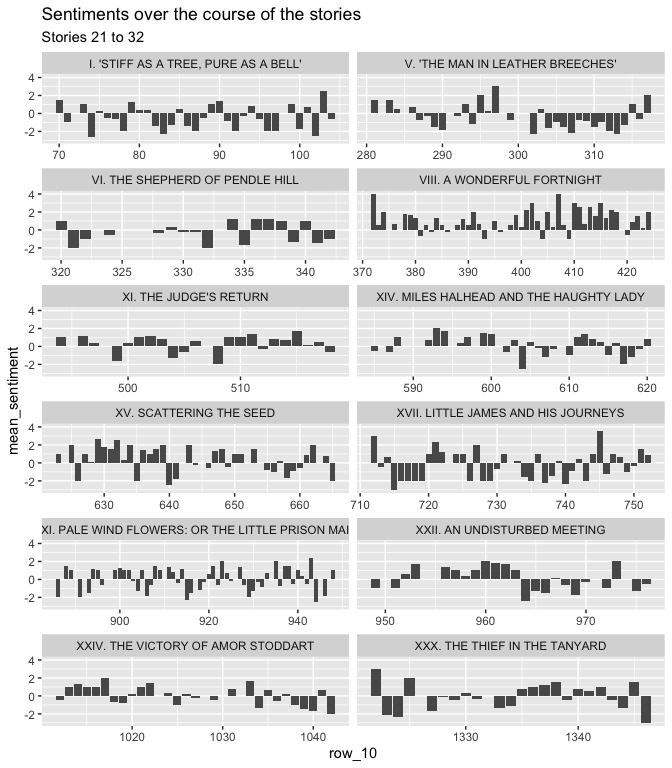

```r
  qs_afinn |>
  filter(text_type == "Story") |>
  # Select just the first 10 stories
  filter(section_title %in% unique(section_title)[21:32]) |>
  # I'm going to make groups of 10 rows to do together.
  # I could use modulo instead.
  mutate(row_10 = round(row_number/10), 0) |>
  arrange(row_10) |>
  group_by(section_title, row_10) |>
  summarize(mean_sentiment = mean(value)) |>
ggplot( aes(x= row_10, y = mean_sentiment)) +
  geom_col(show.legend = FALSE) +
  facet_wrap(~section_title, ncol = 2, scales = "free_x") +
  labs(title = "Sentiments over the course of the stories",
      subtitle = "Stories 21 to 32")
```

This shows us a bit more in the way of narrative structure than using the bing classificiations. There seem to be some stories with positive endings and some with negative endings, and we might want to investigate whether there are patterns to these differences.

Just as with the bing analysis, there are many additional ways we could analyze these data. What is useful is going to depend on your text and the questions you are interested in.